# Yelp Review-2

-Submitted By: Nibhrat, Raunak, Peter

## Abstract

Yelp reviews shared by service users for businesses are valuable for both business owners and prospective customers. The reviews consists of text description, star ratings, reviewer’s information etc. People can also vote on user reviews if they find it useful, funny or cool. The aim of our project is to predict user ratings and sentiments using the enormous review data released by Yelp. Here, we plan to conduct a sentiment analysis of the text description of reviews received for businesses in Charlotte. The idea is to find attributes that result in high ratings and thus suggest improvements in certain services in order to attract more customers. Some of the questions we will be interested in includes; how well we can guess a review's rating from its text alone? What are the most common positive and negative words used in our reviews? Can we extract tips from reviews?

### Preparation

The user review data has been publicly released by Yelp for dataset challenge (https://www.yelp.com/dataset_challenge). The released data consists of 2.7M reviews and 649K tips by 687K users for 86K businesses. However, to simplify our approach, we have only considered review data of Charlotte City. We used 3 major categories of data namely; Business, Review and User. These broad categories consists of attributes of similar class, the details of which were listed in the previous report. The final variables used for the analysis are discussed in detail whenever they appear or are added.

The review data is a complex dataset across multiple dimensions. The attributes we have used are mostly those which have at least 70% data present and thus are statistically significant. The only feature that is not allowed for missing values is the business ID. The decision to remove such rows were taken for the following reasons:

1. They constitute of less than 1% of total restaurants and are statistically insignificant.
2. There is no other way that these business ID’s can be recovered thus making the merging process practically impossible.

For the User's dataset, we have classified users based on clustering algorithms and thus have reduced the features of that dataset to 1. We have also used PCA on the clusters to have a better distinction among them. Thus in this dataset, we finally have 10 clusters to classify the type of users and represent their attributes. The clustering procedure used is K-Means.

#### Task to solve

In this second part of the project here our focus is on to predict the future of the business and classify if they are likely to go out of business in the coming quarter. These results can further be used in discovering factors that lead to failures and thus help businesses to improve upon their existing revenues. Also, if required, a cost analysis can be performed to test the implication, for example; the cost associated with misclassifying a potential shutdown of the business or misclassifying a popular & growing restaurant can be compared.

### Metrics used for evaluation:

Considering the Categorical nature of most features and binary classification of the restaurant status, we have used 3 main metrics for evaluation namely: Precision, F-1 and Recall. Precision: This metric has been particularly used to measure the inaccuracy in detecting the business that are expected to shut down but are predicted as open. This is important considering the risk/cost associated with such a misclassification. It is better to predict low risk as high risk business than to misclassify the high risk as low risk. Recall: This metric is important to determine the robustness of our model. It depicts the number of Negative samples that are predicted as Negatives. This metric is important to not miss any of the high risk cases. F1 Score: It is the harmonic mean of Precision and Recall and thus weights both of the measures for optimization.

### Cross Validation:

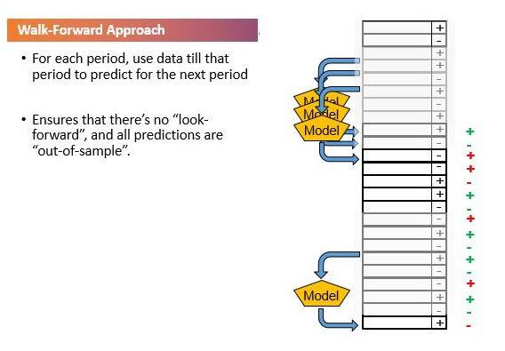

```python
from IPython.display import Image
Image(filename='D:/Yelp/Walk.JPG')
```

```python
# Import required modules
from __future__ import division

import os
import sys
import pandas as pd
pd.set_option('display.width', 500)
pd.set_option('display.max_columns', 100)
pd.set_option('display.notebook_repr_html', True)

import numpy as np
import matplotlib as mpl
import matplotlib.cm as cm
import matplotlib.pyplot as plt
import seaborn as sns
sns.set_style("whitegrid")

# import plotly
# from plotly.offline import download_plotlyjs, init_notebook_mode, plot, iplot
# init_notebook_mode(connected=True)
# import plotly.plotly as py
# from plotly.graph_objs import *

from nltk.sentiment.vader import SentimentIntensityAnalyzer
# from nltk import tokenize
import nltk
from textblob import TextBlob
import math
from joblib import Parallel, delayed
import multiprocessing


from calendar import monthrange
from datetime import datetime, timedelta


from sklearn.decomposition import PCA
from scipy import sparse

from sklearn.ensemble import RandomForestClassifier as rf
from sklearn.neural_network import MLPClassifier
from sklearn.ensemble import VotingClassifier

%matplotlib inline
```

### Read Business dataset

```python
business_df = pd.read_csv(".\Data\yelp_academic_dataset_business.csv")
charlotte_business = business_df.loc[business_df['city'] == 'Charlotte']
food_charlotte_business = pd.DataFrame()
food_categories = ['Food','Restaurants','Nightlife']
for index,row in charlotte_business.iterrows():
    if any(category in row.categories for category in food_categories):
        food_charlotte_business = food_charlotte_business.append(row)
del business_df,charlotte_business

# # Convert selected columns to boolean type
# col_dict_bool = {'attributes.Accepts Credit Cards':np.bool,'attributes.Accepts Insurance':np.bool,
#                  'attributes.Ambience.casual':np.bool,'attributes.Ambience.classy':np.bool,'attributes.Ambience.divey':np.bool,
#                  'attributes.Ambience.hipster':np.bool,'attributes.Ambience.intimate':np.bool,
#                  'attributes.Ambience.romantic':np.bool,'attributes.Ambience.touristy':np.bool,
#                  'attributes.Ambience.trendy':np.bool, 'attributes.Ambience.upscale':np.bool,'attributes.BYOB':np.bool,
#                  'attributes.By Appointment Only':np.bool,
#                  'attributes.Caters':np.bool,'attributes.Coat Check':np.bool,'attributes.Corkage':np.bool,
#                  'attributes.Delivery':np.bool,'attributes.Dietary Restrictions.dairy-free':np.bool,
#                  'attributes.Dietary Restrictions.gluten-free':np.bool,
#                  'attributes.Dietary Restrictions.halal':np.bool,'attributes.Dietary Restrictions.kosher':np.bool,
#                  'attributes.Dietary Restrictions.soy-free':np.bool,'attributes.Dietary Restrictions.vegan':np.bool,
#                  'attributes.Dietary Restrictions.vegetarian':np.bool,'attributes.Dogs Allowed':np.bool,
#                  'attributes.Drive-Thru':np.bool,'attributes.Good For Dancing':np.bool,'attributes.Good For Groups':np.bool,
#                  'attributes.Good For.breakfast':np.bool,'attributes.Good For.brunch':np.bool,
#                  'attributes.Good For.dessert':np.bool,'attributes.Good For.dinner':np.bool,
#                  'attributes.Good For.latenight':np.bool,'attributes.Good For.lunch':np.bool,'attributes.Good for Kids':np.bool,
#                  'attributes.Happy Hour':np.bool,'attributes.Has TV':np.bool,'attributes.Music.background_music':np.bool,
#                  'attributes.Music.dj':np.bool,'attributes.Music.jukebox':np.bool,
#                  'attributes.Music.karaoke':np.bool,'attributes.Music.live':np.bool,
#                  'attributes.Music.video':np.bool,'attributes.Open 24 Hours':np.bool,'attributes.Order at Counter':np.bool,
#                  'attributes.Outdoor Seating':np.bool,'attributes.Parking.garage':np.bool,'attributes.Parking.lot':np.bool,
#                  'attributes.Parking.street':np.bool,'attributes.Parking.valet':np.bool,'attributes.Parking.validated':np.bool,
#                  'attributes.Take-out':np.bool,'attributes.Takes Reservations':np.bool,'attributes.Waiter Service':np.bool,
#                  'attributes.Wheelchair Accessible' :np.bool, 'open':np.bool
#                 }
# map_dict = {0:False, 1:True}
# # Mapping
# for col in food_charlotte_business.columns:
#     if col in col_dict_bool.keys():
#         food_charlotte_business[col] = food_charlotte_business[col].map(map_dict)

#Drop columns that have only NaN
food_charlotte_business = food_charlotte_business.dropna(axis = 1,how = 'all')
print (food_charlotte_business.shape)
```

```
C:\Users\Raunak Mundada\Anaconda3\lib\site-packages\IPython\core\interactiveshell.py:2717: DtypeWarning:

Columns (1,4,7,17,26,29,49,60,62,79,86,94) have mixed types. Specify dtype option on import or set low_memory=False.
```

```
(2744, 90)
```

```python
na_perc = {}
for col in food_charlotte_business.columns:
    na_perc[col] = food_charlotte_business[col].isnull().sum()*100/len(food_charlotte_business)

for key,value in na_perc.items():
    if value > 70:
        food_charlotte_business.drop(key,axis = 1,inplace=True)
food_charlotte_business.shape
```

```
(2744, 63)
```

```python
neighborhoods_1 = list()
neighborhoods_2 = list()
for item in food_charlotte_business.neighborhoods:
    ngh = item.strip('[]')
    ngh = ngh.strip().split(',')
    if (len(ngh) == 1) and ngh[0] != "":
        #print ("Only one neighborhood")
        neighborhoods_1.append(ngh[0].strip("'"))
        neighborhoods_2.append(np.nan)
    elif (len(ngh) == 2):
        #print ("Two neighboorhoods")
        neighborhoods_1.append(ngh[0].strip("'"))
        neighborhoods_2.append(ngh[1].strip("'"))
    else:
        #print ("No Neighborhood")
        neighborhoods_1.append(np.nan)
        neighborhoods_2.append(np.nan)

food_charlotte_business['neighborhoods_1'] = pd.Series(neighborhoods_1,index = food_charlotte_business.index)
food_charlotte_business['neighborhoods_2'] = pd.Series(neighborhoods_2,index = food_charlotte_business.index)
```

```python
food_charlotte_business['neighborhoods'] = food_charlotte_business['neighborhoods_1'].fillna('Other')
food_charlotte_business['attributes.Alcohol'] = food_charlotte_business['attributes.Alcohol'].fillna('none')
food_charlotte_business.fillna(0,inplace=True)
```

Compute the working hours/mins for each business

```python
weekday = ['Monday','Tuesday','Wednesday','Thursday','Friday','Saturday','Sunday']
discard_columns = []
for day in weekday:
    temp = [col for col in food_charlotte_business.columns if day in col]
    discard_columns.append(temp[0])
    discard_columns.append(temp[1])
    food_charlotte_business[day] = abs(pd.to_datetime(food_charlotte_business[temp[1]])-
                                       pd.to_datetime(food_charlotte_business[temp[0]])).astype('timedelta64[m]')
```

```python
# Discard columns that are not required
discard_columns.append('city')
discard_columns.append('type')
discard_columns.append('full_address')
discard_columns.append('neighborhoods_1')
discard_columns.append('neighborhoods_2')
discard_columns.append('state')
discard_columns.append('name')
discard_columns.append('categories')
food_charlotte_business.drop(discard_columns,axis = 1,inplace=True)
```

```python
food_charlotte_business.head()
```

|  | attributes.Accepts Credit Cards | attributes.Alcohol | attributes.Ambience.casual | attributes.Ambience.classy | attributes.Ambience.divey | attributes.Ambience.hipster | attributes.Ambience.intimate | attributes.Ambience.romantic | attributes.Ambience.touristy | attributes.Ambience.trendy | attributes.Ambience.upscale | attributes.Attire | attributes.Caters | attributes.Delivery | attributes.Good For Groups | attributes.Good For.breakfast | attributes.Good For.brunch | attributes.Good For.dessert | attributes.Good For.dinner | attributes.Good For.latenight | attributes.Good For.lunch | attributes.Good for Kids | attributes.Has TV | attributes.Noise Level | attributes.Outdoor Seating | attributes.Parking.garage | attributes.Parking.lot | attributes.Parking.street | attributes.Parking.valet | … |
| --- | --- | --- | --- | --- | --- | --- | --- | --- | --- | --- | --- | --- | --- | --- | --- | --- | --- | --- | --- | --- | --- | --- | --- | --- | --- | --- | --- | --- | --- | --- |
| 889 | 1.0 | none | 0.0 | 0.0 | 0.0 | 0.0 | 0.0 | 0.0 | 0.0 | 0.0 | 0.0 | casual | 1.0 | 0.0 | 1.0 | 0.0 | 1.0 | 0.0 | 0.0 | 0.0 | 0.0 | 1.0 | 0.0 | average | 1.0 | 0.0 | 0.0 | 0.0 | 0.0 | … |
| 902 | 0.0 | none | 0.0 | 0.0 | 0.0 | 0.0 | 0.0 | 0.0 | 0.0 | 0.0 | 0.0 | 0 | 0.0 | 1.0 | 0.0 | 0.0 | 0.0 | 0.0 | 0.0 | 0.0 | 0.0 | 0.0 | 0.0 | 0 | 0.0 | 0.0 | 0.0 | 0.0 | 0.0 | … |
| 933 | 1.0 | none | 1.0 | 0.0 | 0.0 | 0.0 | 0.0 | 0.0 | 0.0 | 0.0 | 0.0 | casual | 0.0 | 0.0 | 1.0 | 0.0 | 0.0 | 0.0 | 0.0 | 0.0 | 1.0 | 1.0 | 0.0 | average | 0.0 | 0.0 | 0.0 | 1.0 | 0.0 | … |
| 935 | 1.0 | none | 0.0 | 0.0 | 0.0 | 0.0 | 0.0 | 0.0 | 0.0 | 0.0 | 0.0 | 0 | 0.0 | 0.0 | 0.0 | 0.0 | 0.0 | 0.0 | 0.0 | 0.0 | 0.0 | 0.0 | 0.0 | 0 | 0.0 | 1.0 | 0.0 | 0.0 | 0.0 | … |
| 938 | 1.0 | full_bar | 0.0 | 0.0 | 0.0 | 0.0 | 1.0 | 0.0 | 0.0 | 0.0 | 0.0 | formal | 0.0 | 0.0 | 1.0 | 0.0 | 0.0 | 0.0 | 1.0 | 0.0 | 0.0 | 0.0 | 0.0 | quiet | 0.0 | 0.0 | 0.0 | 0.0 | 1.0 | … |

### Read Reviews dataset

```python
reviews = pd.read_csv('./Data/yelp_academic_dataset_review.csv')
food_charlotte_reviews = reviews.loc[reviews['business_id'].isin(food_charlotte_business['business_id'])]
del reviews
food_charlotte_reviews.date = pd.to_datetime(food_charlotte_reviews['date'])
```

### Merge reviews and business data sets

```python
charlotte = food_charlotte_reviews.merge(food_charlotte_business,how = 'inner',on= 'business_id')
charlotte.date = pd.to_datetime(charlotte['date'])
charlotte.rename(index = str,columns = {'stars_y':'avg_rating','stars_x':'review_rating'},inplace=True)
```

```python
del food_charlotte_reviews
```

### Sentiment analysis using NLTK

We have used Natural Language Processing methods for sentiment analysis of reviews. The NLTK has predefined libraries which have weight defined for positive, negative and nuetral keywords. Each word in the sentence is processed and the review is assigned collective probabilities for Positive Negative and Nuetral Class.

```python
%%time
sid = SentimentIntensityAnalyzer()
def sentimentAnalysis(text):
#     ss = TextBlob(text).correct()
    ss = sid.polarity_scores(text)
    return (ss)

if __name__ == '__main__':
    num_cores = multiprocessing.cpu_count()
    results = Parallel(n_jobs = -1,backend = 'threading')(delayed(sentimentAnalysis)(sentence) for sentence in charlotte.text)
```

```
Wall time: 22min 9s
```

```python
sentiment = [list(res.values()) for res in results]
sentiment = pd.DataFrame(sentiment,index = charlotte.index,columns = ['neg','compound','neutral','pos'])
frames = [charlotte,sentiment]
charlotte = pd.concat(frames,axis = 1)
```

### User Analysis

```python
user = pd.read_csv('./Data/yelp_academic_dataset_user.csv')
charlotte_user = user.loc[user['user_id'].isin(charlotte['user_id'])]
del user
```

```python
print(charlotte_user.isnull().sum())
charlotte_user=charlotte_user.fillna(0)
```

```
yelping_since              0
compliments.plain      26330
review_count               0
friends                    0
compliments.cute       32777
compliments.writer     28445
fans                       0
compliments.note       27286
type                       0
compliments.hot        29545
compliments.cool       27895
compliments.profile    32451
average_stars              0
compliments.more       30026
elite                      0
name                       0
user_id                    0
votes.cool                 0
compliments.list       33110
votes.funny                0
compliments.photos     31338
compliments.funny      29874
votes.useful               0
dtype: int64
```

```python
charlotte_user['elite_count'] = [len(eval(item)) for item in charlotte_user['elite']]
charlotte_user['friends_count'] = [len(eval(item)) for item in charlotte_user['friends']]
end_date = max(charlotte['date']) # Get end date of the entire data set
charlotte_user['yelp_days']=end_date - pd.to_datetime(charlotte_user['yelping_since'])
user_cluster = charlotte_user.drop(['user_id','friends','elite','name','type','yelping_since'],axis =1)
user_cluster['yelp_days'] = [item.days for item in user_cluster['yelp_days']]
```

```
Wall time: 4min 27s
```

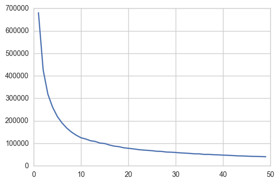

```python
%%time
from sklearn.preprocessing import StandardScaler
from sklearn.pipeline import Pipeline
from sklearn.cluster import KMeans

scl = StandardScaler()
X = scl.fit_transform(user_cluster)

total=0
output=np.array(range(1,50))

for i in range(1,50):
    total=0
    clustercount=i
    kmeans = KMeans(n_clusters=clustercount)
    tempfit=kmeans.fit(X)
    centers=tempfit.cluster_centers_
    for j in range(0,len(centers)):
        testcenter=centers[j]
        points=X[tempfit.labels_==j]
        total+=np.sum(np.linalg.norm(points-testcenter)**2)
    output[i-1]=total

plt.plot(range(1,50),output)
```

As seen from this graph; the knee appears to be around 9 to 11. Thus an estimate of 10 clusters is made.

```python
kmeans = KMeans(n_clusters=10)
kmeans.fit(X)
kmeans.get_params
kmeans.cluster_centers_
labels = kmeans.labels_
labels.shape
```

```
(34008,)
```

```python
user_cluster['user_id'] = charlotte_user['user_id']
user_cluster['cluster_label'] = labels
user_cluster['cluster_label'].value_counts()
```

```
1    13441
4    12296
7     6474
0     1539
6      201
9       36
2       17
5        2
8        1
3        1
Name: cluster_label, dtype: int64
```

#### PCA of cluster analysis

As discussed before, this is done to have a better visualization of the clusters.

```
(34008, 2)
```

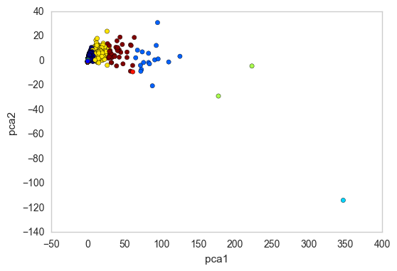

```python
# this function definition just formats the weights into readable strings
# you can skip it without loss of generality to the Data Science content
def get_feature_names_from_weights(weights, names):
    tmp_array = []
    for comp in weights:
        tmp_string = ''
        for fidx,f in enumerate(names):
            if fidx>0 and comp[fidx]>=0:
                tmp_string+='+'
            tmp_string += '%.2f*%s ' % (comp[fidx],f[:-5])
        tmp_array.append(tmp_string)
    return tmp_array

# now let's get to the Data Analytics!
# pca_weight_strings = get_feature_names_from_weights(pca.components_, user_cluster.columns)
#lda_weight_strings = get_feature_names_from_weights(lda.scalings_.T, X.feature_names)
pca = PCA(n_components = 2)
X_pca = pca.fit(X).transform(X)

axislabels= ['pca1','pca2']
# create some pandas dataframes from the transformed outputs
df_pca = pd.DataFrame(X_pca,columns=[axislabels])
#df_lda = pd.DataFrame(X_lda,columns=[lda_weight_strings])

from pandas.tools.plotting import scatter_plot
import matplotlib.cm as cm
print(df_pca.shape)

# scatter plot the output, with the names created from the weights
plt.figure()
ax = scatter_plot(df_pca, axislabels[0], axislabels[1], c=labels,cmap = 'jet')
#ax = scatter_plot(df_lda, lda_weight_strings[0], lda_weight_strings[1], c=y, s=(y+2)*10)
plt.show()
```

Add cluster information

```python
user_cluster_sub = user_cluster[['user_id','cluster_label']]
charlotte = charlotte.merge(user_cluster_sub,how = 'inner', on = 'user_id')
```

### Feature Engineering

```python
# http://stackoverflow.com/questions/7015587/python-difference-of-2-datetimes-in-months
def monthdelta(d1, d2):
    delta = 0
    while True:
        mdays = monthrange(d1.year, d1.month)[1]
        d1 += timedelta(days=mdays)
        if d1 <= d2:
            delta += 1
        else:
            break
    return delta
```

```python
%%time
df = []
start_date = charlotte.date.min()
last_date = charlotte.date.max()
# month_period = monthdelta(start_date,last_date)
date_range = pd.date_range(start_date,last_date,freq='3M')
num = 0
for business_id in charlotte.business_id.unique():
    b_data = charlotte[charlotte.business_id == business_id]
    d1 = start_date
    flag = 0
    for d in date_range[1:]:
        # subset month data
        sub = (b_data.date>=d1)&(b_data.date<d)
        temp = b_data.loc[sub]
        if temp.empty == False:
            # For the first month
            if d1 == start_date:
                users = temp.user_id.unique()
                unique_users_count = len(users)
            else:
                unique_users = [u for u in temp['user_id'] if u not in users.tolist()] # Get unique users
                users = np.append(users,unique_users) # Add unique users to existing users
                unique_users_count = len(unique_users) # Total unique users for the month

            clusters = temp.loc[temp['user_id'].isin(users)].cluster_label.value_counts()
            review_count = temp.review_id.count() # Total reviews
            max_rating = temp.review_rating.max() # Max review rating
            min_rating = temp.review_rating.min() # Min Review rating
            avg_rating = temp['review_rating'].mean() # Mean review rating
            review_count_useful = temp['votes.useful'].count() # Useful reviews
            review_count_cool = temp['votes.cool'].count() # Cool reviews
            review_count_funny = temp['votes.funny'].count() # Funny reviews
            active_period = 1 # Active month
            no_months_first_review = monthdelta(start_date,d)
            no_months_last_review = 0 # No of months since the last review
            avg_pos = temp['pos'].mean()
            avg_neg = temp['neg'].mean()
            avg_neutral = temp['neutral'].mean()
            review_d = d
            flag = 1
        elif (temp.empty==True and flag == 0):
            num+=1
            continue
        else:
            active_period = 0
            no_months_last_review = monthdelta(review_d,d)
            no_months_first_review = monthdelta(start_date,d)

        # add to data frame
        df.append([business_id,d,review_count,max_rating,min_rating,avg_rating,review_count_useful,
                   review_count_cool,review_count_funny,unique_users_count,active_period,no_months_last_review,clusters])
        d1 = d # Assign 'start date' as the current month
        num+=1
        sys.stderr.write('\rEpoch: %d' % num)
        sys.stderr.flush()
```

```
Epoch: 124890
```

```
Wall time: 4min 28s
```

```python
df = pd.DataFrame(df,columns=['business_id','Period_EndDate','Review_Count','Max_rating','Min_rating','Avg_rating',
                             'Review_count_Useful','Review_count_Cool','Review_count_Funny','Unique_users_count',
                             'Active_period','Months_since_Last_review','Cluster_count'])
```

Add business attributes

```python
df = df.merge(food_charlotte_business,on = 'business_id',how='inner')
df.head()
```

|  | business_id | Period_EndDate | Review_Count | Max_rating | Min_rating | Avg_rating | Review_count_Useful | Review_count_Cool | Review_count_Funny | Unique_users_count | Active_period | Months_since_Last_review | Cluster_count | attributes.Accepts Credit Cards | attributes.Alcohol | attributes.Ambience.casual | attributes.Ambience.classy | attributes.Ambience.divey | attributes.Ambience.hipster | attributes.Ambience.intimate | attributes.Ambience.romantic | attributes.Ambience.touristy | attributes.Ambience.trendy | attributes.Ambience.upscale | attributes.Attire | attributes.Caters | attributes.Delivery | attributes.Good For Groups | attributes.Good For.breakfast | … |
| --- | --- | --- | --- | --- | --- | --- | --- | --- | --- | --- | --- | --- | --- | --- | --- | --- | --- | --- | --- | --- | --- | --- | --- | --- | --- | --- | --- | --- | --- | --- |
| 0 | Gw5POFxBRoJxN_ZYhk6lgQ | 2011-03-31 | 1 | 4 | 4 | 4.0 | 1 | 1 | 1 | 1 | 1 | 0 | 0 1 Name: cluster_label, dtype: int64 | 1.0 | none | 0.0 | 0.0 | 0.0 | 0.0 | 0.0 | 0.0 | 0.0 | 0.0 | 0.0 | casual | 1.0 | 0.0 | 1.0 | 0.0 | … |
| 1 | Gw5POFxBRoJxN_ZYhk6lgQ | 2011-06-30 | 1 | 4 | 4 | 4.0 | 1 | 1 | 1 | 1 | 0 | 2 | 0 1 Name: cluster_label, dtype: int64 | 1.0 | none | 0.0 | 0.0 | 0.0 | 0.0 | 0.0 | 0.0 | 0.0 | 0.0 | 0.0 | casual | 1.0 | 0.0 | 1.0 | 0.0 | … |
| 2 | Gw5POFxBRoJxN_ZYhk6lgQ | 2011-09-30 | 1 | 5 | 5 | 5.0 | 1 | 1 | 1 | 1 | 1 | 0 | 4 1 Name: cluster_label, dtype: int64 | 1.0 | none | 0.0 | 0.0 | 0.0 | 0.0 | 0.0 | 0.0 | 0.0 | 0.0 | 0.0 | casual | 1.0 | 0.0 | 1.0 | 0.0 | … |
| 3 | Gw5POFxBRoJxN_ZYhk6lgQ | 2011-12-31 | 1 | 5 | 5 | 5.0 | 1 | 1 | 1 | 1 | 0 | 3 | 4 1 Name: cluster_label, dtype: int64 | 1.0 | none | 0.0 | 0.0 | 0.0 | 0.0 | 0.0 | 0.0 | 0.0 | 0.0 | 0.0 | casual | 1.0 | 0.0 | 1.0 | 0.0 | … |
| 4 | Gw5POFxBRoJxN_ZYhk6lgQ | 2012-03-31 | 1 | 5 | 5 | 5.0 | 1 | 1 | 1 | 1 | 0 | 5 | 4 1 Name: cluster_label, dtype: int64 | 1.0 | none | 0.0 | 0.0 | 0.0 | 0.0 | 0.0 | 0.0 | 0.0 | 0.0 | 0.0 | casual | 1.0 | 0.0 | 1.0 | 0.0 | … |

```python
# Data tidying for cluster count
cluster_count = df.Cluster_count
cluster_df = [pd.DataFrame(item).reindex(index=range(10))for item in cluster_count]
cluster_df = pd.concat(cluster_df,axis=1)
```

```python
cluster_df = cluster_df.transpose()
cluster_df.columns = ['Cluster_'+ str(i) for i in range(10)]
x = list(range(len(df)))
cluster_df = cluster_df.set_index([x])
cluster_df = cluster_df.fillna(0)
cluster_df.head()
```

|  | Cluster_0 | Cluster_1 | Cluster_2 | Cluster_3 | Cluster_4 | Cluster_5 | Cluster_6 | Cluster_7 | Cluster_8 | Cluster_9 |
| --- | --- | --- | --- | --- | --- | --- | --- | --- | --- | --- |
| 0 | 1.0 | 0.0 | 0.0 | 0.0 | 0.0 | 0.0 | 0.0 | 0.0 | 0.0 | 0.0 |
| 1 | 1.0 | 0.0 | 0.0 | 0.0 | 0.0 | 0.0 | 0.0 | 0.0 | 0.0 | 0.0 |
| 2 | 0.0 | 0.0 | 0.0 | 0.0 | 1.0 | 0.0 | 0.0 | 0.0 | 0.0 | 0.0 |
| 3 | 0.0 | 0.0 | 0.0 | 0.0 | 1.0 | 0.0 | 0.0 | 0.0 | 0.0 | 0.0 |
| 4 | 0.0 | 0.0 | 0.0 | 0.0 | 1.0 | 0.0 | 0.0 | 0.0 | 0.0 | 0.0 |

```python
# Add cluster label information
frames = [df,cluster_df]
df = pd.concat(frames,axis=1)
df.drop(['Cluster_count','business_id'],axis=1,inplace=True)
```

```python
final_df = pd.get_dummies(df)
final_df.head()
```

|  | Period_EndDate | Review_Count | Max_rating | Min_rating | Avg_rating | Review_count_Useful | Review_count_Cool | Review_count_Funny | Unique_users_count | Active_period | Months_since_Last_review | attributes.Accepts Credit Cards | attributes.Ambience.casual | attributes.Ambience.classy | attributes.Ambience.divey | attributes.Ambience.hipster | attributes.Ambience.intimate | attributes.Ambience.romantic | attributes.Ambience.touristy | attributes.Ambience.trendy | attributes.Ambience.upscale | attributes.Caters | attributes.Delivery | attributes.Good For Groups | attributes.Good For.breakfast | attributes.Good For.brunch | attributes.Good For.dessert | attributes.Good For.dinner | attributes.Good For.latenight | … |
| --- | --- | --- | --- | --- | --- | --- | --- | --- | --- | --- | --- | --- | --- | --- | --- | --- | --- | --- | --- | --- | --- | --- | --- | --- | --- | --- | --- | --- | --- | --- |
| 0 | 2011-03-31 | 1 | 4 | 4 | 4.0 | 1 | 1 | 1 | 1 | 1 | 0 | 1.0 | 0.0 | 0.0 | 0.0 | 0.0 | 0.0 | 0.0 | 0.0 | 0.0 | 0.0 | 1.0 | 0.0 | 1.0 | 0.0 | 1.0 | 0.0 | 0.0 | 0.0 | … |
| 1 | 2011-06-30 | 1 | 4 | 4 | 4.0 | 1 | 1 | 1 | 1 | 0 | 2 | 1.0 | 0.0 | 0.0 | 0.0 | 0.0 | 0.0 | 0.0 | 0.0 | 0.0 | 0.0 | 1.0 | 0.0 | 1.0 | 0.0 | 1.0 | 0.0 | 0.0 | 0.0 | … |
| 2 | 2011-09-30 | 1 | 5 | 5 | 5.0 | 1 | 1 | 1 | 1 | 1 | 0 | 1.0 | 0.0 | 0.0 | 0.0 | 0.0 | 0.0 | 0.0 | 0.0 | 0.0 | 0.0 | 1.0 | 0.0 | 1.0 | 0.0 | 1.0 | 0.0 | 0.0 | 0.0 | … |
| 3 | 2011-12-31 | 1 | 5 | 5 | 5.0 | 1 | 1 | 1 | 1 | 0 | 3 | 1.0 | 0.0 | 0.0 | 0.0 | 0.0 | 0.0 | 0.0 | 0.0 | 0.0 | 0.0 | 1.0 | 0.0 | 1.0 | 0.0 | 1.0 | 0.0 | 0.0 | 0.0 | … |
| 4 | 2012-03-31 | 1 | 5 | 5 | 5.0 | 1 | 1 | 1 | 1 | 0 | 5 | 1.0 | 0.0 | 0.0 | 0.0 | 0.0 | 0.0 | 0.0 | 0.0 | 0.0 | 0.0 | 1.0 | 0.0 | 1.0 | 0.0 | 1.0 | 0.0 | 0.0 | 0.0 | … |

5 rows × 109 columns

```python
final_df = pd.read_csv('D:/Yelp/final_df.csv')
final_df['Period_EndDate'] = pd.to_datetime(final_df['Period_EndDate'])
final_df.head()
```

|  | Unnamed: 0 | Period_EndDate | Review_Count | Max_rating | Min_rating | Avg_rating | Review_count_Useful | Review_count_Cool | Review_count_Funny | Unique_users_count | Active_period | Months_since_Last_review | attributes.Accepts Credit Cards | attributes.Ambience.casual | attributes.Ambience.classy | attributes.Ambience.divey | attributes.Ambience.hipster | attributes.Ambience.intimate | attributes.Ambience.romantic | attributes.Ambience.touristy | attributes.Ambience.trendy | attributes.Ambience.upscale | attributes.Caters | attributes.Delivery | attributes.Good For Groups | attributes.Good For.breakfast | attributes.Good For.brunch | attributes.Good For.dessert | attributes.Good For.dinner | … |
| --- | --- | --- | --- | --- | --- | --- | --- | --- | --- | --- | --- | --- | --- | --- | --- | --- | --- | --- | --- | --- | --- | --- | --- | --- | --- | --- | --- | --- | --- | --- |
| 0 | 0 | 2011-03-31 | 1 | 4 | 4 | 4.0 | 1 | 1 | 1 | 1 | 1 | 0 | 1.0 | 0.0 | 0.0 | 0.0 | 0.0 | 0.0 | 0.0 | 0.0 | 0.0 | 0.0 | 1.0 | 0.0 | 1.0 | 0.0 | 1.0 | 0.0 | 0.0 | … |
| 1 | 1 | 2011-06-30 | 1 | 4 | 4 | 4.0 | 1 | 1 | 1 | 1 | 0 | 2 | 1.0 | 0.0 | 0.0 | 0.0 | 0.0 | 0.0 | 0.0 | 0.0 | 0.0 | 0.0 | 1.0 | 0.0 | 1.0 | 0.0 | 1.0 | 0.0 | 0.0 | … |
| 2 | 2 | 2011-09-30 | 1 | 5 | 5 | 5.0 | 1 | 1 | 1 | 1 | 1 | 0 | 1.0 | 0.0 | 0.0 | 0.0 | 0.0 | 0.0 | 0.0 | 0.0 | 0.0 | 0.0 | 1.0 | 0.0 | 1.0 | 0.0 | 1.0 | 0.0 | 0.0 | … |
| 3 | 3 | 2011-12-31 | 1 | 5 | 5 | 5.0 | 1 | 1 | 1 | 1 | 0 | 3 | 1.0 | 0.0 | 0.0 | 0.0 | 0.0 | 0.0 | 0.0 | 0.0 | 0.0 | 0.0 | 1.0 | 0.0 | 1.0 | 0.0 | 1.0 | 0.0 | 0.0 | … |
| 4 | 4 | 2012-03-31 | 1 | 5 | 5 | 5.0 | 1 | 1 | 1 | 1 | 0 | 5 | 1.0 | 0.0 | 0.0 | 0.0 | 0.0 | 0.0 | 0.0 | 0.0 | 0.0 | 0.0 | 1.0 | 0.0 | 1.0 | 0.0 | 1.0 | 0.0 | 0.0 | … |

5 rows × 110 columns

## Classification

As discussed before; a time series analysis has been performed and businesses are classified in the High risk(Close) and no risk category(Open). Various algorithms used are shown below:

```python
from dateutil.relativedelta import relativedelta
from sklearn.linear_model import LogisticRegression
from sklearn.svm import SVC
from sklearn import metrics as mt

def build_model(final_df,clf_obj):
    period_relative = relativedelta(months = 3)
    period = pd.to_datetime(final_df.Period_EndDate.unique()).sort_values()
    sub_period = period[8:]
    metrics = []
    clf = []
    num = 0

    for date in sub_period:
        train = final_df[final_df.Period_EndDate <= date]
        train = train.drop('Period_EndDate',axis = 1)

        test = final_df[final_df.Period_EndDate == (date+period_relative)]
        test = test.drop('Period_EndDate',axis=1)

        if test.empty == False:
            X_train = train.drop('open',axis=1,inplace=False).values
            Y_train = train['open'].values

            X_test = test.drop('open',axis=1,inplace=False).values
            Y_test = test['open'].values

            clf_obj.fit(X_train,Y_train)
            Y_hat = clf_obj.predict(X_test)

            #Compute relevant metrics
            acc = mt.accuracy_score(Y_test,Y_hat)
            cm_metrics = mt.precision_recall_fscore_support(Y_test,Y_hat,average = 'binary',pos_label = 0)
            class_count = np.unique(Y_test,return_counts = True)[1]
            class_ratio = class_count[0]/class_count[1]
            metrics.append([date,acc,len(X_train),len(X_test),cm_metrics[0],cm_metrics[1],
                           cm_metrics[2],class_ratio])
            clf.append(clf_obj)
        else:
            continue

        num+=1
        sys.stderr.write('\rEpoch: %d' %num)
        sys.stderr.flush()

    return(clf,metrics)
```

```python
def plot_metrics(metrics):
    metrics = metrics.drop(['Train_Data_Size','Test_Data_Size'],axis = 1,inplace = False)
    metrics['Date'] = metrics['Date'].dt.date
    metrics_df = pd.melt(metrics,id_vars=['Date','reg_param'],value_vars=['Accuracy','Precision',
                                                                          'Recall','F1_Score','Class_Ratio'],
                        var_name = 'Name',value_name='Metrics')

    grouped = metrics_df.groupby('reg_param')
    nrows = int(len(grouped.groups)/2)
    sns.set_style("whitegrid")

    fig,ax = plt.subplots(nrows,2,figsize = (20,20))
    for (ind,group),ax in zip(grouped,ax.flat):
        ax.set_frame_on(False)
        ax.set_title(("Regularization="+str(ind)),fontsize=20)
        ax.set_xlabel("Test Period",fontsize = 14)
        ax.set_ylabel("Metric Value",fontsize =14)
        g = sns.pointplot(data = group,x="Date",y = "Metrics",hue = "Name",ax=ax,legend=False)
        g.set(ylim=(0.5,1))
        xticks = [item.get_text() for item in ax.get_xticklabels()]
        ax.set_xticklabels(labels = xticks,rotation = 90)
        g.legend_.remove()
        plt.tight_layout()
    plt.legend()
```

### Logistic Regression

For the llogistic regression, we have varied the regularization parameter (from 0.001 to 1000 with multiplicative increments of 10) and plotted various parameters to select the best one.

```python
%%time

## Logistic Regression
reg_param = [0.001, 0.01, 0.1, 1, 10, 100, 1000]
metrics_df = pd.DataFrame()

for c in reg_param:
    clf_lr = LogisticRegression(penalty = 'l2',C = c,class_weight = 'balanced',warm_start = True,
                                n_jobs = -1,solver = 'lbfgs')
    clf_perf = build_model(final_df,clf_lr)
    metrics = clf_perf[1]
    metrics = pd.DataFrame(metrics,columns = ['Date','Accuracy','Train_Data_Size','Test_Data_Size',
                                              'Precision','Recall','F1_Score','Class_Ratio'])
    metrics['reg_param'] = c
#     weights = np.array(clf_perf[0].coef_[0])
    # weights = np.array(clf_perf[2])
    # plot_weight(weights)
    metrics_df = pd.concat((metrics_df,metrics))
```

```
Epoch: 28
```

```
Wall time: 13min 13s
```

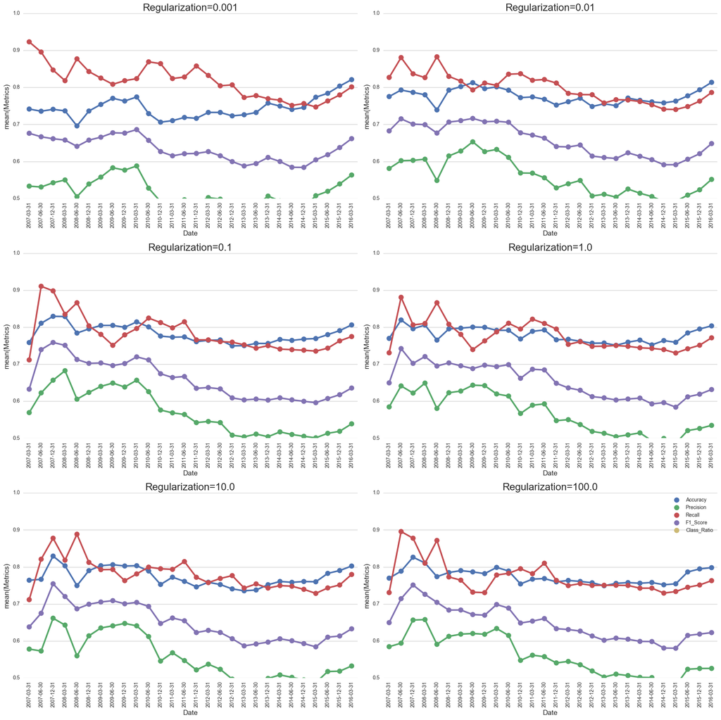

```python
metrics_df_lr = metrics_df
plot_metrics(metrics_df_lr)
```

```python
metrics_df_lr.groupby('reg_param').describe()
```

| reg_param |  | Accuracy | Class_Ratio | F1_Score | Precision | Recall | Test_Data_Size | Train_Data_Size |
| --- | --- | --- | --- | --- | --- | --- | --- | --- |
| 0.001 | count | 28.000000 | 28.000000 | 28.000000 | 28.000000 | 28.000000 | 28.000000 | 28.000000 |
|  | mean | 0.744698 | 0.373649 | 0.633262 | 0.518421 | 0.816076 | 1570.642857 | 20259.964286 |
|  | std | 0.028613 | 0.053921 | 0.031780 | 0.034449 | 0.045478 | 827.411726 | 17680.584045 |
|  | min | 0.696028 | 0.279384 | 0.583932 | 0.474286 | 0.747049 | 178.000000 | 416.000000 |
|  | 25% | 0.728456 | 0.327463 | 0.609219 | 0.491407 | 0.776536 | 864.250000 | 4474.750000 |
|  | 50% | 0.738463 | 0.378936 | 0.626647 | 0.506932 | 0.818182 | 1675.000000 | 15695.500000 |
|  | 75% | 0.759067 | 0.424506 | 0.661419 | 0.540067 | 0.843831 | 2293.500000 | 33945.500000 |
|  | max | 0.820999 | 0.448148 | 0.686076 | 0.587852 | 0.923077 | 2743.000000 | 55844.000000 |
| 0.010 | count | 28.000000 | 28.000000 | 28.000000 | 28.000000 | 28.000000 | 28.000000 | 28.000000 |
|  | mean | 0.776022 | 0.373649 | 0.657036 | 0.558971 | 0.798738 | 1570.642857 | 20259.964286 |
|  | std | 0.019927 | 0.053921 | 0.043297 | 0.048879 | 0.038983 | 827.411726 | 17680.584045 |
|  | min | 0.739206 | 0.279384 | 0.591093 | 0.491582 | 0.740304 | 178.000000 | 416.000000 |
|  | 25% | 0.761207 | 0.327463 | 0.614343 | 0.513465 | 0.765203 | 864.250000 | 4474.750000 |
|  | 50% | 0.773316 | 0.378936 | 0.655664 | 0.550067 | 0.799287 | 1675.000000 | 15695.500000 |
|  | 75% | 0.792726 | 0.424506 | 0.702112 | 0.603721 | 0.826565 | 2293.500000 | 33945.500000 |
|  | max | 0.813708 | 0.448148 | 0.716263 | 0.652997 | 0.882682 | 2743.000000 | 55844.000000 |
| 0.100 | count | 28.000000 | 28.000000 | 28.000000 | 28.000000 | 28.000000 | 28.000000 | 28.000000 |
|  | mean | 0.782125 | 0.373649 | 0.658182 | 0.569306 | 0.782556 | 1570.642857 | 20259.964286 |
|  | std | 0.023495 | 0.053921 | 0.052170 | 0.058943 | 0.049027 | 827.411726 | 17680.584045 |
|  | min | 0.749392 | 0.279384 | 0.596036 | 0.501149 | 0.711538 | 178.000000 | 416.000000 |
|  | 25% | 0.764499 | 0.327463 | 0.608536 | 0.512814 | 0.748322 | 864.250000 | 4474.750000 |
|  | 50% | 0.774742 | 0.378936 | 0.636296 | 0.554794 | 0.765673 | 1675.000000 | 15695.500000 |
|  | 75% | 0.801644 | 0.424506 | 0.702542 | 0.624245 | 0.805707 | 2293.500000 | 33945.500000 |
|  | max | 0.829268 | 0.448148 | 0.758621 | 0.682432 | 0.910448 | 2743.000000 | 55844.000000 |
| 1.000 | count | 28.000000 | 28.000000 | 28.000000 | 28.000000 | 28.000000 | 28.000000 | 28.000000 |
|  | mean | 0.779382 | 0.373649 | 0.653824 | 0.566095 | 0.776216 | 1570.642857 | 20259.964286 |
|  | std | 0.019490 | 0.053921 | 0.045632 | 0.053856 | 0.039442 | 827.411726 | 17680.584045 |
|  | min | 0.751034 | 0.279384 | 0.583951 | 0.486517 | 0.730185 | 178.000000 | 416.000000 |
|  | 25% | 0.763283 | 0.327463 | 0.611096 | 0.517411 | 0.747157 | 864.250000 | 4474.750000 |
|  | 50% | 0.777071 | 0.378936 | 0.649018 | 0.558524 | 0.761928 | 1675.000000 | 15695.500000 |
|  | 75% | 0.795390 | 0.424506 | 0.695213 | 0.620225 | 0.806557 | 2293.500000 | 33945.500000 |
|  | max | 0.819383 | 0.448148 | 0.742138 | 0.649007 | 0.880597 | 2743.000000 | 55844.000000 |
| 10.000 | count | 28.000000 | 28.000000 | 28.000000 | 28.000000 | 28.000000 | 28.000000 | 28.000000 |
|  | mean | 0.772507 | 0.373649 | 0.648033 | 0.556348 | 0.779120 | 1570.642857 | 20259.964286 |
|  | std | 0.025153 | 0.053921 | 0.048509 | 0.058222 | 0.040926 | 827.411726 | 17680.584045 |
|  | min | 0.735529 | 0.279384 | 0.584178 | 0.484812 | 0.711538 | 178.000000 | 416.000000 |
|  | 25% | 0.752574 | 0.327463 | 0.605996 | 0.506670 | 0.749132 | 864.250000 | 4474.750000 |
|  | 50% | 0.762526 | 0.378936 | 0.635361 | 0.541506 | 0.774241 | 1675.000000 | 15695.500000 |
|  | 75% | 0.793276 | 0.424506 | 0.694740 | 0.612421 | 0.796157 | 2293.500000 | 33945.500000 |
|  | max | 0.829268 | 0.448148 | 0.754386 | 0.661538 | 0.888268 | 2743.000000 | 55844.000000 |
| 100.000 | count | 28.000000 | 28.000000 | 28.000000 | 28.000000 | 28.000000 | 28.000000 | 28.000000 |
|  | mean | 0.774731 | 0.373649 | 0.647729 | 0.559610 | 0.771730 | 1570.642857 | 20259.964286 |
|  | std | 0.020012 | 0.053921 | 0.045754 | 0.053642 | 0.044759 | 827.411726 | 17680.584045 |
|  | min | 0.749176 | 0.279384 | 0.580387 | 0.480132 | 0.729272 | 178.000000 | 416.000000 |
|  | 25% | 0.757546 | 0.327463 | 0.612026 | 0.516886 | 0.744390 | 864.250000 | 4474.750000 |
|  | 50% | 0.769108 | 0.378936 | 0.640835 | 0.546203 | 0.753096 | 1675.000000 | 15695.500000 |
|  | 75% | 0.788669 | 0.424506 | 0.683457 | 0.613062 | 0.781950 | 2293.500000 | 33945.500000 |
|  | max | 0.826220 | 0.448148 | 0.751092 | 0.657718 | 0.895522 | 2743.000000 | 55844.000000 |
| 1000.000 | count | 28.000000 | 28.000000 | 28.000000 | 28.000000 | 28.000000 | 28.000000 | 28.000000 |
|  | mean | 0.777918 | 0.373649 | 0.655000 | 0.563086 | 0.785229 | 1570.642857 | 20259.964286 |
|  | std | 0.018307 | 0.053921 | 0.042659 | 0.050349 | 0.040299 | 827.411726 | 17680.584045 |
|  | min | 0.748905 | 0.279384 | 0.589588 | 0.492099 | 0.734024 | 178.000000 | 416.000000 |
|  | 25% | 0.762389 | 0.327463 | 0.614098 | 0.518993 | 0.756693 | 864.250000 | 4474.750000 |
|  | 50% | 0.772538 | 0.378936 | 0.648122 | 0.555327 | 0.767637 | 1675.000000 | 15695.500000 |
|  | 75% | 0.791687 | 0.424506 | 0.695191 | 0.600113 | 0.810746 | 2293.500000 | 33945.500000 |
|  | max | 0.810742 | 0.448148 | 0.731884 | 0.651613 | 0.880597 | 2743.000000 | 55844.000000 |

### SVM

Support Vector Machines is another algorithm that we have tried. Tuning the Regularization parameter and gamma have produced results of high precision. The summary of the metric measures is given below.

```python
%%time
## SVM
# Linear SVM
reg_param = [0.001, 0.01, 0.1, 1, 10, 100, 1000]
gamma = [0.00001,0.0001,0.01,0.1,1,10]

def rbfSVM(c,g):
    metrics_df = pd.DataFrame()
    clf_rbfSVM = SVC(kernel = 'rbf',C=c,gamma = g,class_weight = 'balanced',random_state = 1)
    clf_perf = build_model(final_df,clf_rbfSVM)
    metrics = clf_perf[1]
    metrics = pd.DataFrame(metrics,columns = ['Date','Accuracy','Train_Data_Size','Test_Data_Size',
                                              'Precision','Recall','F1_Score','Class_Ratio'])
    metrics['reg_param'] = c
    metrics['gamma'] = g
    return (metrics)

if __name__ == '__main__':
    num_cores = multiprocessing.cpu_count()
    metrics_df = Parallel(n_jobs = -1,backend = 'threading')(delayed(rbfSVM)(c,g) for c,g in zip(reg_param,gamma))
```

```
C:\Users\Raunak Mundada\Anaconda3\lib\site-packages\sklearn\metrics\classification.py:1074: UndefinedMetricWarning:

Precision and F-score are ill-defined and being set to 0.0 due to no predicted samples.

Epoch: 28
```

```
Wall time: 6h 21min 19s
```

```python
metrics_df_svm = pd.concat(metrics_df)
metrics_df_svm.to_csv("D:/Yelp/SVM_Metrics.csv")
# metrics_df_svm = pd.read_csv('D:/Yelp/SVM_Metrics.csv')
metrics_df_svm.groupby(['reg_param','gamma']).describe()
```

| reg_param | gamma |  | Accuracy | Class_Ratio | F1_Score | Precision | Recall | Test_Data_Size | Train_Data_Size |
| --- | --- | --- | --- | --- | --- | --- | --- | --- | --- |
| 0.001 | 0.00001 | count | 28.000000 | 28.000000 | 28.000000 | 28.000000 | 28.000000 | 28.000000 | 28.000000 |
|  |  | mean | 0.551374 | 0.373649 | 0.355087 | 0.282879 | 0.535823 | 1570.642857 | 20259.964286 |
|  |  | std | 0.146259 | 0.053921 | 0.135309 | 0.104083 | 0.312498 | 827.411726 | 17680.584045 |
|  |  | min | 0.295154 | 0.279384 | 0.000000 | 0.000000 | 0.000000 | 178.000000 | 416.000000 |
|  |  | 25% | 0.450119 | 0.327463 | 0.338478 | 0.286775 | 0.413080 | 864.250000 | 4474.750000 |
|  |  | 50% | 0.621609 | 0.378936 | 0.372465 | 0.306725 | 0.430046 | 1675.000000 | 15695.500000 |
|  |  | 75% | 0.634069 | 0.424506 | 0.456612 | 0.326287 | 0.845783 | 2293.500000 | 33945.500000 |
|  |  | max | 0.707865 | 0.448148 | 0.485757 | 0.388764 | 1.000000 | 2743.000000 | 55844.000000 |
| 0.010 | 0.00010 | count | 28.000000 | 28.000000 | 28.000000 | 28.000000 | 28.000000 | 28.000000 | 28.000000 |
|  |  | mean | 0.639172 | 0.373649 | 0.416077 | 0.378746 | 0.499836 | 1570.642857 | 20259.964286 |
|  |  | std | 0.090307 | 0.053921 | 0.084224 | 0.096730 | 0.178846 | 827.411726 | 17680.584045 |
|  |  | min | 0.292135 | 0.279384 | 0.000000 | 0.000000 | 0.000000 | 178.000000 | 416.000000 |
|  |  | 25% | 0.639364 | 0.327463 | 0.414263 | 0.340631 | 0.415374 | 864.250000 | 4474.750000 |
|  |  | 50% | 0.657501 | 0.378936 | 0.426388 | 0.368376 | 0.481944 | 1675.000000 | 15695.500000 |
|  |  | 75% | 0.683226 | 0.424506 | 0.436981 | 0.458205 | 0.529595 | 2293.500000 | 33945.500000 |
|  |  | max | 0.704846 | 0.448148 | 0.497890 | 0.508621 | 1.000000 | 2743.000000 | 55844.000000 |
| 0.100 | 0.01000 | count | 28.000000 | 28.000000 | 28.000000 | 28.000000 | 28.000000 | 28.000000 | 28.000000 |
|  |  | mean | 0.808338 | 0.373649 | 0.649147 | 0.647902 | 0.688909 | 1570.642857 | 20259.964286 |
|  |  | std | 0.032239 | 0.053921 | 0.097511 | 0.062181 | 0.172893 | 827.411726 | 17680.584045 |
|  |  | min | 0.744493 | 0.279384 | 0.347826 | 0.569620 | 0.230769 | 178.000000 | 416.000000 |
|  |  | 25% | 0.792857 | 0.327463 | 0.647526 | 0.587611 | 0.623879 | 864.250000 | 4474.750000 |
|  |  | 50% | 0.798869 | 0.378936 | 0.660293 | 0.637553 | 0.740348 | 1675.000000 | 15695.500000 |
|  |  | 75% | 0.816818 | 0.424506 | 0.683337 | 0.695813 | 0.767230 | 2293.500000 | 33945.500000 |
|  |  | max | 0.888808 | 0.448148 | 0.787456 | 0.791667 | 0.943239 | 2743.000000 | 55844.000000 |
| 1.000 | 0.10000 | count | 28.000000 | 28.000000 | 28.000000 | 28.000000 | 28.000000 | 28.000000 | 28.000000 |
|  |  | mean | 0.927307 | 0.373649 | 0.859782 | 0.900887 | 0.830056 | 1570.642857 | 20259.964286 |
|  |  | std | 0.026137 | 0.053921 | 0.052751 | 0.031614 | 0.095862 | 827.411726 | 17680.584045 |
|  |  | min | 0.859551 | 0.279384 | 0.691358 | 0.865248 | 0.538462 | 178.000000 | 416.000000 |
|  |  | 25% | 0.920100 | 0.327463 | 0.853438 | 0.876524 | 0.799332 | 864.250000 | 4474.750000 |
|  |  | 50% | 0.932912 | 0.378936 | 0.872787 | 0.891900 | 0.861149 | 1675.000000 | 15695.500000 |
|  |  | 75% | 0.942006 | 0.424506 | 0.884798 | 0.913125 | 0.883804 | 2293.500000 | 33945.500000 |
|  |  | max | 0.967814 | 0.448148 | 0.929326 | 0.975610 | 0.954925 | 2743.000000 | 55844.000000 |
| 10.000 | 1.00000 | count | 28.000000 | 28.000000 | 28.000000 | 28.000000 | 28.000000 | 28.000000 | 28.000000 |
|  |  | mean | 0.744564 | 0.373649 | 0.107095 | 0.958796 | 0.057258 | 1570.642857 | 20259.964286 |
|  |  | std | 0.024598 | 0.053921 | 0.046657 | 0.059485 | 0.026029 | 827.411726 | 17680.584045 |
|  |  | min | 0.708440 | 0.279384 | 0.029412 | 0.800000 | 0.014925 | 178.000000 | 416.000000 |
|  |  | 25% | 0.720118 | 0.327463 | 0.071571 | 0.919167 | 0.037306 | 864.250000 | 4474.750000 |
|  |  | 50% | 0.748644 | 0.378936 | 0.114733 | 1.000000 | 0.060915 | 1675.000000 | 15695.500000 |
|  |  | 75% | 0.763023 | 0.424506 | 0.135557 | 1.000000 | 0.072706 | 2293.500000 | 33945.500000 |
|  |  | max | 0.785272 | 0.448148 | 0.191083 | 1.000000 | 0.105634 | 2743.000000 | 55844.000000 |
| 100.000 | 10.00000 | count | 28.000000 | 28.000000 | 28.000000 | 28.000000 | 28.000000 | 28.000000 | 28.000000 |
|  |  | mean | 0.741748 | 0.373649 | 0.087859 | 0.970639 | 0.046420 | 1570.642857 | 20259.964286 |
|  |  | std | 0.025152 | 0.053921 | 0.039946 | 0.047285 | 0.021903 | 827.411726 | 17680.584045 |
|  |  | min | 0.705882 | 0.279384 | 0.023102 | 0.846154 | 0.011686 | 178.000000 | 416.000000 |
|  |  | 25% | 0.716633 | 0.327463 | 0.052996 | 0.960317 | 0.027244 | 864.250000 | 4474.750000 |
|  |  | 50% | 0.744154 | 0.378936 | 0.093343 | 1.000000 | 0.049002 | 1675.000000 | 15695.500000 |
|  |  | 75% | 0.761737 | 0.424506 | 0.112179 | 1.000000 | 0.059424 | 2293.500000 | 33945.500000 |
|  |  | max | 0.784178 | 0.448148 | 0.163793 | 1.000000 | 0.089202 | 2743.000000 | 55844.000000 |

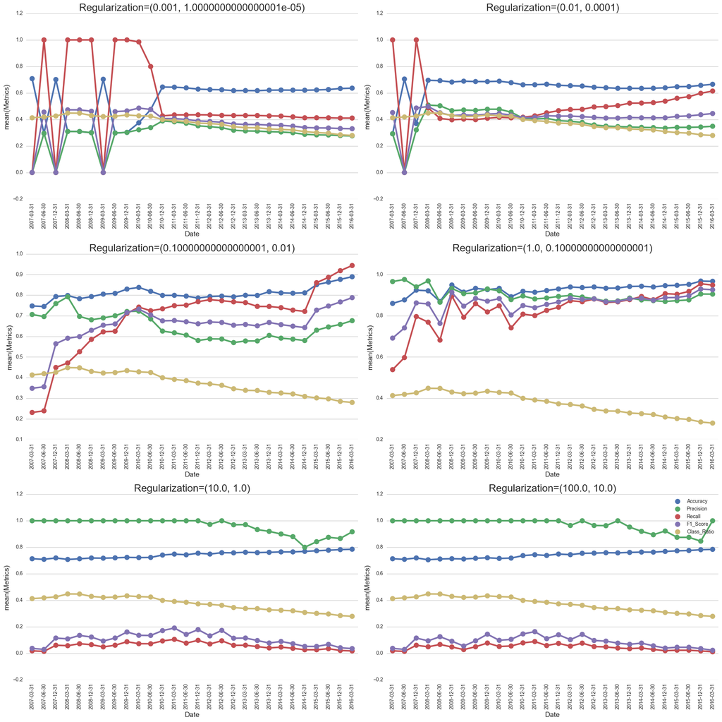

```python
metrics_df_svm['Date'] = metrics_df_svm['Date'].dt.date
metrics_df = pd.melt(metrics_df_svm,id_vars=['Date','reg_param','gamma'],value_vars=['Accuracy','Precision',
                                                                      'Recall','F1_Score','Class_Ratio'],
                     var_name = 'Name',value_name='Metrics')
grouped = metrics_df.groupby(['reg_param','gamma'])
nrows = int(len(grouped.groups)/2)
sns.set_style("whitegrid")

fig,ax = plt.subplots(nrows,2,figsize = (20,20))
for (ind,group),ax in zip(grouped,ax.flat):
    ax.set_frame_on(False)
    ax.set_title(("Regularization="+str(ind)),fontsize=20)
    ax.set_xlabel("Test Period",fontsize = 14)
    ax.set_ylabel("Metric Value",fontsize =14)
    g = sns.pointplot(data = group,x="Date",y = "Metrics",hue = "Name",ax=ax,legend=False)
    xticks = [item.get_text() for item in ax.get_xticklabels()]
    ax.set_xticklabels(labels = xticks,rotation = 90)
    g.legend_.remove()
    plt.tight_layout()
plt.legend()
```

Optimizing the Precision, F-1 and Recall, using the above plots, we select C = 1 and gamma = 0.1 as our SVM parameter values.

### Multi-layer Perceptron

```python
## MLP
from sklearn.neural_network import MLPClassifier
metrics_df = pd.DataFrame()
layer_size = [(10,),(50,),(10,10),(50,50),(100,100),(10,10,10),(50,50,50)]
for layer in layer_size:
    clf_mlp = MLPClassifier(hidden_layer_sizes=layer,warm_start=True,activation = 'logistic',random_state=1)
    clf_perf = build_model(final_df,clf_mlp)
    metrics = clf_perf[1]
    metrics = pd.DataFrame(metrics,columns = ['Date','Accuracy','Train_Data_Size','Test_Data_Size',
                                          'Precision','Recall','F1_Score','Class_Ratio'])
#     metrics['reg_param'] = np.sum(list(layer))
    metrics['reg_param'] = str(layer)
    metrics_df = pd.concat((metrics_df,metrics))
```

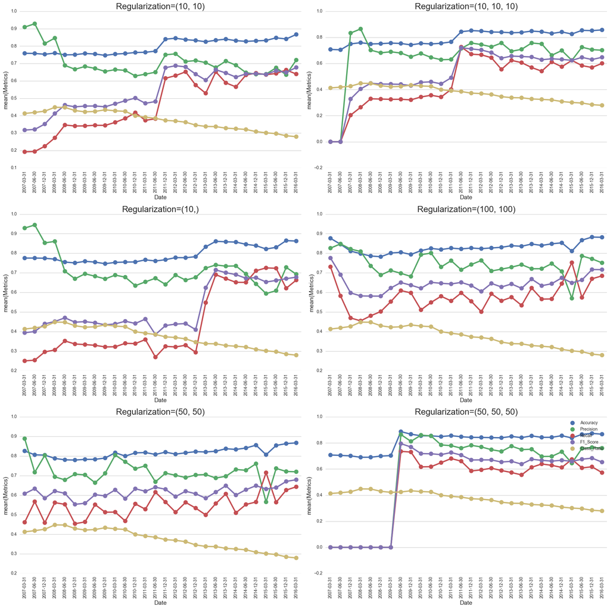

```python
metrics_df_mlp = metrics_df
plot_metrics(metrics_df_mlp)
```

MLP with layer size of (100,100) is selected considering higher metric scores. A summary containing mean, Standard deviation and quartiles of various evaluation metrices is shown below:

```python
metrics_df_mlp.groupby('reg_param').describe()
```

| reg_param |  | Accuracy | Class_Ratio | F1_Score | Precision | Recall | Test_Data_Size | Train_Data_Size |
| --- | --- | --- | --- | --- | --- | --- | --- | --- |
| (10, 10) | count | 28.000000 | 28.000000 | 28.000000 | 28.000000 | 28.000000 | 28.000000 | 28.000000 |
|  | mean | 0.797407 | 0.373649 | 0.543101 | 0.706403 | 0.470986 | 1570.642857 | 20259.964286 |
|  | std | 0.042051 | 0.053921 | 0.119319 | 0.079438 | 0.161339 | 827.411726 | 17680.584045 |
|  | min | 0.746562 | 0.279384 | 0.317460 | 0.628253 | 0.192308 | 178.000000 | 416.000000 |
|  | 25% | 0.757523 | 0.327463 | 0.455593 | 0.653241 | 0.344660 | 864.250000 | 4474.750000 |
|  | 50% | 0.798005 | 0.378936 | 0.552869 | 0.679838 | 0.473074 | 1675.000000 | 15695.500000 |
|  | 75% | 0.834541 | 0.424506 | 0.646138 | 0.717717 | 0.634326 | 2293.500000 | 33945.500000 |
|  | max | 0.866934 | 0.448148 | 0.687225 | 0.928571 | 0.662771 | 2743.000000 | 55844.000000 |
| (10, 10, 10) | count | 28.000000 | 28.000000 | 28.000000 | 28.000000 | 28.000000 | 28.000000 | 28.000000 |
|  | mean | 0.798266 | 0.373649 | 0.523276 | 0.657733 | 0.453992 | 1570.642857 | 20259.964286 |
|  | std | 0.051270 | 0.053921 | 0.186084 | 0.193849 | 0.195850 | 827.411726 | 17680.584045 |
|  | min | 0.704846 | 0.279384 | 0.000000 | 0.000000 | 0.000000 | 178.000000 | 416.000000 |
|  | 25% | 0.753061 | 0.327463 | 0.442356 | 0.660020 | 0.327051 | 864.250000 | 4474.750000 |
|  | 50% | 0.827983 | 0.378936 | 0.626317 | 0.700671 | 0.548040 | 1675.000000 | 15695.500000 |
|  | 75% | 0.843259 | 0.424506 | 0.648061 | 0.731989 | 0.607768 | 2293.500000 | 33945.500000 |
|  | max | 0.857091 | 0.448148 | 0.720539 | 0.864865 | 0.726244 | 2743.000000 | 55844.000000 |
| (10,) | count | 28.000000 | 28.000000 | 28.000000 | 28.000000 | 28.000000 | 28.000000 | 28.000000 |
|  | mean | 0.793816 | 0.373649 | 0.520347 | 0.710701 | 0.440324 | 1570.642857 | 20259.964286 |
|  | std | 0.042423 | 0.053921 | 0.118899 | 0.086482 | 0.175371 | 827.411726 | 17680.584045 |
|  | min | 0.746562 | 0.279384 | 0.384491 | 0.593923 | 0.250000 | 178.000000 | 416.000000 |
|  | 25% | 0.757925 | 0.327463 | 0.438697 | 0.667364 | 0.321374 | 864.250000 | 4474.750000 |
|  | 50% | 0.775306 | 0.378936 | 0.450884 | 0.688312 | 0.337258 | 1675.000000 | 15695.500000 |
|  | 75% | 0.834403 | 0.424506 | 0.663350 | 0.729483 | 0.651214 | 2293.500000 | 33945.500000 |
|  | max | 0.864595 | 0.448148 | 0.714420 | 0.944444 | 0.725126 | 2743.000000 | 55844.000000 |
| (100, 100) | count | 28.000000 | 28.000000 | 28.000000 | 28.000000 | 28.000000 | 28.000000 | 28.000000 |
|  | mean | 0.829126 | 0.373649 | 0.645411 | 0.742746 | 0.577335 | 1570.642857 | 20259.964286 |
|  | std | 0.027130 | 0.053921 | 0.042798 | 0.055353 | 0.071936 | 827.411726 | 17680.584045 |
|  | min | 0.782152 | 0.279384 | 0.580808 | 0.569604 | 0.454545 | 178.000000 | 416.000000 |
|  | 25% | 0.811002 | 0.327463 | 0.622087 | 0.714596 | 0.544984 | 864.250000 | 4474.750000 |
|  | 50% | 0.826554 | 0.378936 | 0.643774 | 0.738407 | 0.570160 | 1675.000000 | 15695.500000 |
|  | 75% | 0.846127 | 0.424506 | 0.654288 | 0.774917 | 0.600351 | 2293.500000 | 33945.500000 |
|  | max | 0.882723 | 0.448148 | 0.775510 | 0.847826 | 0.752108 | 2743.000000 | 55844.000000 |
| (50, 50) | count | 28.000000 | 28.000000 | 28.000000 | 28.000000 | 28.000000 | 28.000000 | 28.000000 |
|  | mean | 0.816875 | 0.373649 | 0.616596 | 0.719854 | 0.545683 | 1570.642857 | 20259.964286 |
|  | std | 0.024676 | 0.053921 | 0.029421 | 0.055983 | 0.060366 | 827.411726 | 17680.584045 |
|  | min | 0.779528 | 0.279384 | 0.553191 | 0.565333 | 0.454148 | 178.000000 | 416.000000 |
|  | 25% | 0.803617 | 0.327463 | 0.599521 | 0.695873 | 0.512148 | 864.250000 | 4474.750000 |
|  | 50% | 0.816724 | 0.378936 | 0.620037 | 0.712056 | 0.552875 | 1675.000000 | 15695.500000 |
|  | 75% | 0.827823 | 0.424506 | 0.633017 | 0.735681 | 0.564926 | 2293.500000 | 33945.500000 |
|  | max | 0.867299 | 0.448148 | 0.679012 | 0.888889 | 0.715008 | 2743.000000 | 55844.000000 |
| (50, 50, 50) | count | 28.000000 | 28.000000 | 28.000000 | 28.000000 | 28.000000 | 28.000000 | 28.000000 |
|  | mean | 0.814865 | 0.373649 | 0.516076 | 0.574486 | 0.470168 | 1570.642857 | 20259.964286 |
|  | std | 0.068662 | 0.053921 | 0.305346 | 0.340849 | 0.279497 | 827.411726 | 17680.584045 |
|  | min | 0.690537 | 0.279384 | 0.000000 | 0.000000 | 0.000000 | 178.000000 | 416.000000 |
|  | 25% | 0.806017 | 0.327463 | 0.478556 | 0.483871 | 0.416667 | 864.250000 | 4474.750000 |
|  | 50% | 0.843377 | 0.378936 | 0.666974 | 0.750780 | 0.607890 | 1675.000000 | 15695.500000 |
|  | 75% | 0.855380 | 0.424506 | 0.689694 | 0.776756 | 0.631310 | 2293.500000 | 33945.500000 |
|  | max | 0.886986 | 0.448148 | 0.795031 | 0.864865 | 0.735632 | 2743.000000 | 55844.000000 |
| (50,) | count | 28.000000 | 28.000000 | 28.000000 | 28.000000 | 28.000000 | 28.000000 | 28.000000 |
|  | mean | 0.819878 | 0.373649 | 0.594680 | 0.748226 | 0.515011 | 1570.642857 | 20259.964286 |
|  | std | 0.049323 | 0.053921 | 0.135765 | 0.065518 | 0.161284 | 827.411726 | 17680.584045 |
|  | min | 0.745407 | 0.279384 | 0.290323 | 0.625776 | 0.173077 | 178.000000 | 416.000000 |
|  | 25% | 0.758131 | 0.327463 | 0.470712 | 0.708866 | 0.359401 | 864.250000 | 4474.750000 |
|  | 50% | 0.841581 | 0.378936 | 0.651832 | 0.746432 | 0.583270 | 1675.000000 | 15695.500000 |
|  | 75% | 0.860323 | 0.424506 | 0.681776 | 0.777961 | 0.643574 | 2293.500000 | 33945.500000 |
|  | max | 0.872364 | 0.448148 | 0.755172 | 0.900000 | 0.704225 | 2743.000000 | 55844.000000 |

### Random Forest

```python
## Random Forest

n_trees = [10,100,200,500,1000]
metrics_df = pd.DataFrame()
for tree in n_trees:
    clf_rf = rf(n_estimators = tree,criterion='entropy',max_features = 'auto',bootstrap = True,
                n_jobs = -1,class_weight = 'balanced',random_state = 1)
    clf_perf = build_model(final_df,clf_rf)
    metrics = clf_perf[1]
    metrics = pd.DataFrame(metrics,columns = ['Date','Accuracy','Train_Data_Size','Test_Data_Size',
                                          'Precision','Recall','F1_Score','Class_Ratio'])
    metrics['reg_param'] = tree
    metrics_df = pd.concat((metrics_df,metrics))
```

```
Epoch: 28
```

```python
metrics_df_rf = metrics_df
metrics_df_rf.groupby('reg_param').describe()
```

| reg_param |  | Accuracy | Class_Ratio | F1_Score | Precision | Recall | Test_Data_Size | Train_Data_Size |
| --- | --- | --- | --- | --- | --- | --- | --- | --- |
| 10 | count | 28.000000 | 28.000000 | 28.000000 | 28.000000 | 28.000000 | 28.000000 | 28.000000 |
|  | mean | 0.980086 | 0.373649 | 0.965164 | 0.969471 | 0.961186 | 1570.642857 | 20259.964286 |
|  | std | 0.019246 | 0.053921 | 0.029497 | 0.034275 | 0.028461 | 827.411726 | 17680.584045 |
|  | min | 0.896373 | 0.279384 | 0.839572 | 0.805128 | 0.877095 | 178.000000 | 416.000000 |
|  | 25% | 0.976999 | 0.327463 | 0.960886 | 0.971552 | 0.950183 | 864.250000 | 4474.750000 |
|  | 50% | 0.984502 | 0.378936 | 0.971868 | 0.976992 | 0.965082 | 1675.000000 | 15695.500000 |
|  | 75% | 0.991357 | 0.424506 | 0.982326 | 0.983427 | 0.981851 | 2293.500000 | 33945.500000 |
|  | max | 0.995625 | 0.448148 | 0.990066 | 0.992857 | 0.998331 | 2743.000000 | 55844.000000 |
| 100 | count | 28.000000 | 28.000000 | 28.000000 | 28.000000 | 28.000000 | 28.000000 | 28.000000 |
|  | mean | 0.983925 | 0.373649 | 0.971725 | 0.981477 | 0.962298 | 1570.642857 | 20259.964286 |
|  | std | 0.015170 | 0.053921 | 0.024178 | 0.024745 | 0.026123 | 827.411726 | 17680.584045 |
|  | min | 0.922280 | 0.279384 | 0.875346 | 0.868132 | 0.882682 | 178.000000 | 416.000000 |
|  | 25% | 0.980152 | 0.327463 | 0.966366 | 0.980714 | 0.956056 | 864.250000 | 4474.750000 |
|  | 50% | 0.986520 | 0.378936 | 0.975230 | 0.987806 | 0.965462 | 1675.000000 | 15695.500000 |
|  | 75% | 0.992570 | 0.424506 | 0.985007 | 0.994471 | 0.978321 | 2293.500000 | 33945.500000 |
|  | max | 0.999271 | 0.448148 | 0.998333 | 1.000000 | 1.000000 | 2743.000000 | 55844.000000 |
| 200 | count | 28.000000 | 28.000000 | 28.000000 | 28.000000 | 28.000000 | 28.000000 | 28.000000 |
|  | mean | 0.984342 | 0.373649 | 0.972479 | 0.982426 | 0.962842 | 1570.642857 | 20259.964286 |
|  | std | 0.015152 | 0.053921 | 0.024137 | 0.024867 | 0.025529 | 827.411726 | 17680.584045 |
|  | min | 0.922280 | 0.279384 | 0.875346 | 0.868132 | 0.882682 | 178.000000 | 416.000000 |
|  | 25% | 0.980294 | 0.327463 | 0.966656 | 0.982738 | 0.954299 | 864.250000 | 4474.750000 |
|  | 50% | 0.987171 | 0.378936 | 0.976315 | 0.988179 | 0.965050 | 1675.000000 | 15695.500000 |
|  | 75% | 0.993788 | 0.424506 | 0.987219 | 0.994695 | 0.979335 | 2293.500000 | 33945.500000 |
|  | max | 0.999635 | 0.448148 | 0.999166 | 1.000000 | 1.000000 | 2743.000000 | 55844.000000 |
| 500 | count | 28.000000 | 28.000000 | 28.000000 | 28.000000 | 28.000000 | 28.000000 | 28.000000 |
|  | mean | 0.984335 | 0.373649 | 0.972435 | 0.983007 | 0.962230 | 1570.642857 | 20259.964286 |
|  | std | 0.014704 | 0.053921 | 0.023481 | 0.023972 | 0.025752 | 827.411726 | 17680.584045 |
|  | min | 0.925734 | 0.279384 | 0.880886 | 0.873626 | 0.888268 | 178.000000 | 416.000000 |
|  | 25% | 0.982369 | 0.327463 | 0.969510 | 0.982398 | 0.953797 | 864.250000 | 4474.750000 |
|  | 50% | 0.985970 | 0.378936 | 0.974901 | 0.988098 | 0.964971 | 1675.000000 | 15695.500000 |
|  | 75% | 0.993259 | 0.424506 | 0.986381 | 0.994766 | 0.979561 | 2293.500000 | 33945.500000 |
|  | max | 0.999271 | 0.448148 | 0.998331 | 1.000000 | 0.998331 | 2743.000000 | 55844.000000 |
| 1000 | count | 28.000000 | 28.000000 | 28.000000 | 28.000000 | 28.000000 | 28.000000 | 28.000000 |
|  | mean | 0.984715 | 0.373649 | 0.973148 | 0.983138 | 0.963478 | 1570.642857 | 20259.964286 |
|  | std | 0.014623 | 0.053921 | 0.023318 | 0.023948 | 0.025066 | 827.411726 | 17680.584045 |
|  | min | 0.925734 | 0.279384 | 0.880886 | 0.873626 | 0.888268 | 178.000000 | 416.000000 |
|  | 25% | 0.982648 | 0.327463 | 0.968949 | 0.982500 | 0.953797 | 864.250000 | 4474.750000 |
|  | 50% | 0.985970 | 0.378936 | 0.975074 | 0.988347 | 0.965585 | 1675.000000 | 15695.500000 |
|  | 75% | 0.993359 | 0.424506 | 0.986324 | 0.994700 | 0.979561 | 2293.500000 | 33945.500000 |
|  | max | 0.999635 | 0.448148 | 0.999166 | 1.000000 | 1.000000 | 2743.000000 | 55844.000000 |

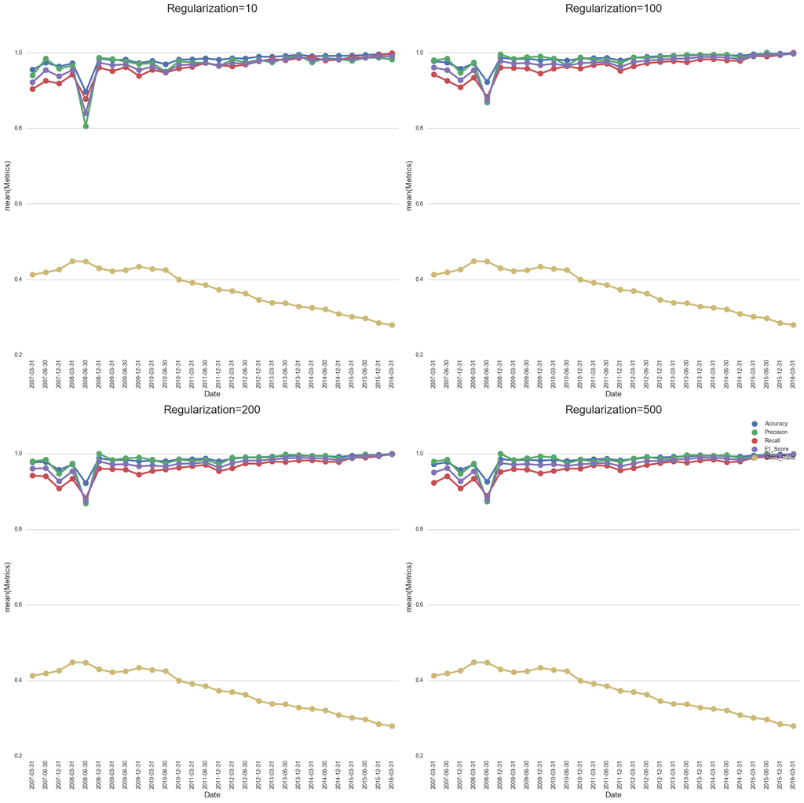

```python
plot_metrics(metrics_df_rf)
```

As clearly seen from the above graphs, the precision is very high. This can be attributed to the overfitting of the model. Also, other parameters like F-1 are also high. This clearly shows that there is an possible overfit of the model while training, the reasons of which can be investigated further. In case there are enough reasons to reject the possibility of an overfit, Random forest can be effective.

### Comparison of best performing models

The algorithms discussed above are compared and tested statistically after using the optimized tuning parameters. The results of 95% significance of area under ROC is presented later.

```python
metrics_df_svm = pd.read_csv('D:/Yelp/SVM_Metrics.csv')
```

[output not shown]

[figure not shown]

```python
rf_best = metrics_df_rf[metrics_df_rf.reg_param == 100]
rf_best['clf'] = 'rf'
svm_best = metrics_df_svm[(metrics_df_svm.gamma==0.1) & (metrics_df_svm.reg_param == 1.0)]
svm_best['clf'] = 'svm'
mlp_best = metrics_df_mlp[metrics_df_mlp.reg_param==str((100,100))]
mlp_best['clf'] = 'mlp'
lr_best = metrics_df_lr[metrics_df_lr.reg_param == 1]
lr_best['clf'] = 'lr'

models_perf = pd.concat([rf_best,svm_best,mlp_best,lr_best])


# models_perf['Date'] = models_perf['Date'].dt.date
models_perf = pd.melt(models_perf,id_vars=['Date','clf'],value_vars=['Accuracy','Precision',
                                                                      'Recall','F1_Score'],
                     var_name = 'Name',value_name='Metrics')
sns.set_style("whitegrid")

fig = plt.figure(figsize=(10,8))
# Add a subplot
ax = fig.add_subplot(111)
ax.set_frame_on(False)
ax.set_title("Model Analysis",fontsize=20)
g = sns.pointplot(data = models_perf,x = "Name",y="Metrics",hue = "clf",joint=False)
ax.set_xlabel("Metric",fontsize = 14)
ax.set_ylabel("Value with 95% confidence Interval",fontsize =14)
plt.legend(title = "Classifier")
```

### Ensemble - Majority Voting

The best performing algorithms are combined into an ensemble and Majority Voting is used.

```python
%%time

clf1 = LogisticRegression(penalty = 'l2',C = 1.0,class_weight = 'balanced',
                                n_jobs = -1,solver = 'lbfgs')
clf2 = SVC(kernel = 'rbf',C=1.0,gamma = 0.1,class_weight = 'balanced',random_state = 1)
clf3 = MLPClassifier(hidden_layer_sizes=(100,100),activation = 'logistic',random_state=1)

eclf = VotingClassifier(estimators=[('lr', clf1), ('svm', clf2), ('mlp', clf3)], voting='hard',
                       n_jobs = -1)
eclf_perf = build_model(final_df,eclf)
metrics = eclf_perf[1]
metrics = pd.DataFrame(metrics,columns = ['Date','Accuracy','Train_Data_Size','Test_Data_Size',
                                          'Precision','Recall','F1_Score','Class_Ratio'])
```

```
Epoch: 28
```

```python
metrics_eclf = metrics
metrics_eclf.to_csv('D:/Yelp/Ensemble_results.csv')
```

```python
metrics_eclf.describe()
```

|  | Accuracy | Train_Data_Size | Test_Data_Size | Precision | Recall | F1_Score | Class_Ratio |
| --- | --- | --- | --- | --- | --- | --- | --- |
| count | 28.000000 | 28.000000 | 28.000000 | 28.000000 | 28.000000 | 28.000000 | 28.000000 |
| mean | 0.901232 | 20259.964286 | 1570.642857 | 0.815312 | 0.823354 | 0.817827 | 0.373649 |
| std | 0.013573 | 17680.584045 | 827.411726 | 0.047759 | 0.038421 | 0.024528 | 0.053921 |
| min | 0.861831 | 416.000000 | 178.000000 | 0.745645 | 0.720812 | 0.759358 | 0.279384 |
| 25% | 0.892606 | 4474.750000 | 864.250000 | 0.779628 | 0.805753 | 0.804118 | 0.327463 |
| 50% | 0.901495 | 15695.500000 | 1675.000000 | 0.803174 | 0.830853 | 0.815494 | 0.378936 |
| 75% | 0.907086 | 33945.500000 | 2293.500000 | 0.846388 | 0.846014 | 0.831470 | 0.424506 |
| max | 0.927087 | 55844.000000 | 2743.000000 | 0.931034 | 0.884808 | 0.866379 | 0.448148 |

[figure not shown]

```python
# metrics_eclf['Date'] = metrics_eclf['Date'].dt.date
metrics_df = pd.melt(metrics_eclf,id_vars=['Date'],value_vars=['Accuracy','Precision',
                                                                      'Recall','F1_Score'],
                     var_name = 'Name',value_name='Metrics')
sns.set_style("whitegrid")

fig = plt.figure(figsize=(10,8))
# Add a subplot
ax = fig.add_subplot(111)
ax.set_frame_on(False)
ax.set_title("Ensemble Analysis",fontsize=20)
ax.set_xlabel("Test Period",fontsize = 14)
ax.set_ylabel("Metric Value",fontsize =14)
g = sns.pointplot(data = metrics_df,x="Date",y = "Metrics",hue = "Name",ax=ax,legend=False)
xticks = [item.get_text() for item in ax.get_xticklabels()]
ax.set_xticklabels(labels = xticks,rotation = 90)
g.legend_.remove()
plt.tight_layout()
plt.legend()
```

## Final Model Analysis

```python
def build_model_finalPeriod(final_df,clf_obj):
    period_relative = relativedelta(months = 3)
    period = pd.to_datetime(final_df.Period_EndDate.unique()).sort_values()
    sub_period = period[len(period)-2]
    date = sub_period
    metrics = []
    clf = []
    num = 0
    train = final_df[final_df.Period_EndDate <= date]
    train = train.drop('Period_EndDate',axis = 1)

    test = final_df[final_df.Period_EndDate == (date+period_relative)]
    test = test.drop('Period_EndDate',axis=1)

    X_train = train.drop('open',axis=1,inplace=False).values
    Y_train = train['open'].values

    X_test = test.drop('open',axis=1,inplace=False).values
    Y_test = test['open'].values

    clf_obj.fit(X_train,Y_train)
    Y_hat = clf_obj.predict(X_test)
    y_score = clf_obj.predict_proba(X_test)

    #Compute relevant metrics
    acc = mt.accuracy_score(Y_test,Y_hat)
    cm = mt.confusion_matrix(Y_test,Y_hat)
    cm_metrics = mt.precision_recall_fscore_support(Y_test,Y_hat,average = 'binary',pos_label = 0)
    class_count = np.unique(Y_test,return_counts = True)[1]
    class_ratio = class_count[0]/class_count[1]
    metrics.append([date,acc,len(X_train),len(X_test),cm_metrics[0],cm_metrics[1],
                    cm_metrics[2],class_ratio])
    clf.append(clf_obj)

    num+=1
    sys.stderr.write('\rEpoch: %d' %num)
    sys.stderr.flush()

    return(clf,metrics,cm,Y_test,Y_hat, y_score)
```

### ROC Curves

```python
from sklearn.preprocessing import label_binarize
from sklearn.metrics import roc_curve, auc
def plot_roc(clf_obj,y_test,y_score,title):
    roc_auc = dict()
    n_classes = 2
    fpr, tpr, _ = roc_curve(y_test, y_score)
    roc_auc = auc(fpr, tpr)

    plt.figure()
    lw = 2
    plt.plot(fpr, tpr, color='darkorange',
             lw=lw, label='ROC curve (area = %0.2f)' % roc_auc)
    plt.plot([0, 1], [0, 1], color='navy', lw=lw, linestyle='--')
    plt.xlim([0.0, 1.0])
    plt.ylim([0.0, 1.05])
    plt.xlabel('False Positive Rate')
    plt.ylabel('True Positive Rate')
    plt.title('Receiver operating characteristic: '+title)
    plt.legend(loc="lower right")
    plt.show()
```

```python
%%time
clf_lr = LogisticRegression(penalty = 'l2',C = 1.0,class_weight = 'balanced',
                                n_jobs = -1,solver = 'lbfgs')
clf_lr_perf = build_model_finalPeriod(final_df,clf_lr)
```

```
Epoch: 1
```

```
Wall time: 7.27 s
```

```python
%%time
clf_svm = SVC(kernel = 'rbf',C=1.0,gamma = 0.1,class_weight = 'balanced',random_state = 1)
clf_svm_perf = build_model_finalPeriod(final_df,clf_svm)
```

```
Epoch: 1
```

```
Wall time: 32min 47s
```

```python
%%time
clf_mlp = MLPClassifier(hidden_layer_sizes=(100,100),activation = 'logistic',random_state=1)
clf_mlp_perf = build_model_finalPeriod(final_df,clf_mlp)
```

```
Epoch: 1
```

```
Wall time: 10.7 s
```

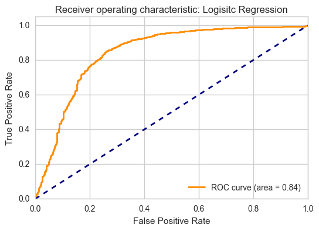

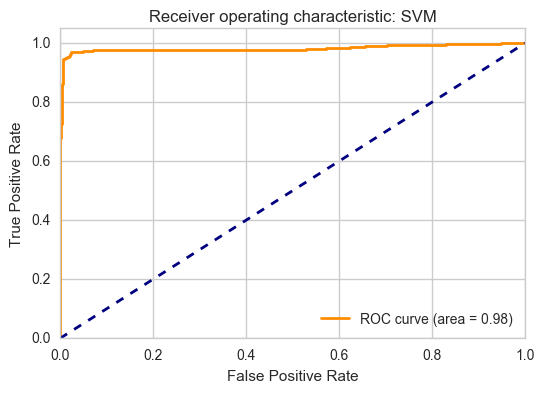

```python
plot_roc(clf_lr,clf_lr_perf[3],clf_lr_perf[5],title="Logisitc Regression")
plot_roc(clf_svm,clf_svm_perf[3],clf_svm_perf[5],title = "SVM")
plot_roc(clf_mlp,clf_mlp_perf[3],clf_mlp_perf[5],title = "MLP")
```

[output not shown]